# Informe desigualdades sociales en factores de riesgo de enfermedad cardiovascular - Cataluña

Proyecto PI21/01868

El presente informe muestra la evolución de la prevalencia y el índice relativo de desigualdad (RII por sus siglas en inglés), en función del nivel educativo, para diferentes factores de riesgo de enfermedad cardiovascular (FRECV) en Cataluña desde el año 2001 hasta el 2020*, utilizando los datos de la Encuesta Nacional de Salud en España/Encuesta Europea de Salud en España.

Los FRECV incluidos en este informe son la diabetes, la hipertensión arterial, la hipercolesterolemia, la obesidad, el sedentarismo, el tabaquismo, el consumo de alcohol y la alimentación (ver definiciones en la sección “Nota metodológica” al final del informe)

Este informe se enmarca dentro del Proyecto PI21/01868 financiado por el Instituto de Salud Carlos III y cofinanciado por la Unión Europea.

**Los datos de los FRECV referidos a los años 2001 y 2009 fueron omitidos de las gráficas debido a cambios en las preguntas de las encuestas que dificultaron la intepretación de los resultados*

# Diabetes

## Prevalencias

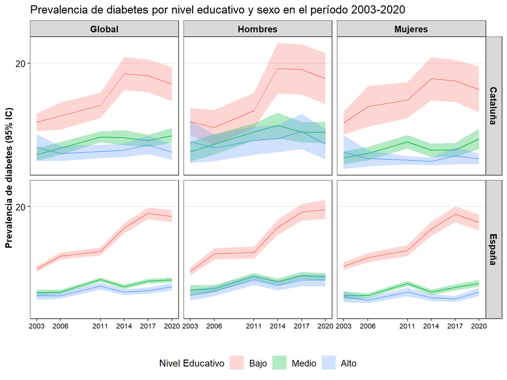

## Desigualdades

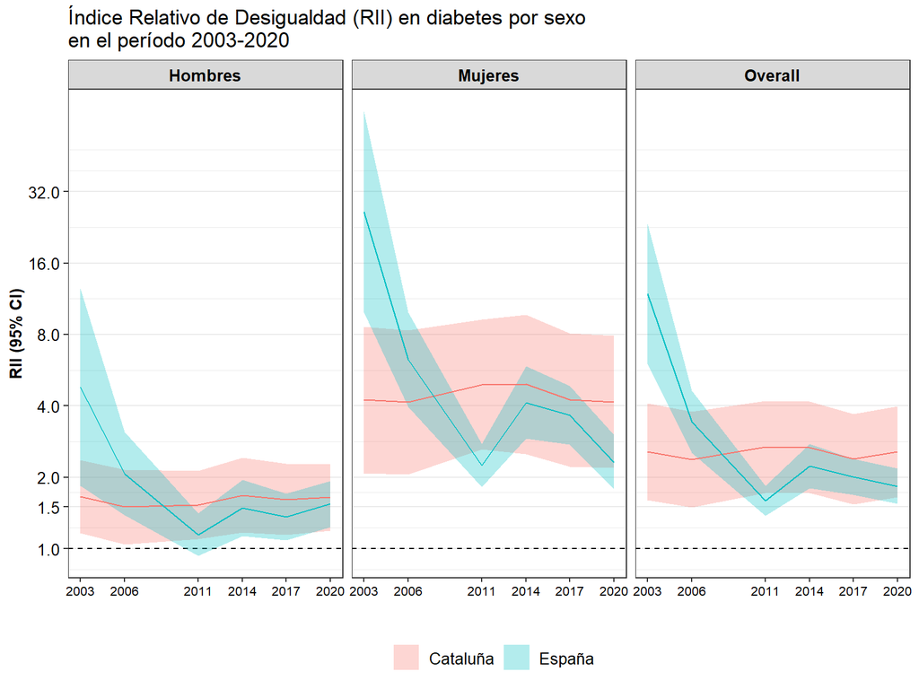